# Analysis

Names:  
Noah Tajalli and Junyun Huang

In this project, we are going to analyze how the average house price in a given city for a given year is affected by different factors. The factors that we are going to analyze are as follows for each city: the year, the median household income, unemployment rate, poverty rate, percentage of population with bachelors degree or higher and total population. When analyzing housing prices, there are so many factors that go into it. These factors can range for demographics to climate to economic state of the country to any number of things. It is impossible as of right now to factor in all these components accurately, otherwise we would already have model that can precisely predict what housing prices will be in the future

The goal of this project is not to necessarily try and create as close to a perfect model as possible, but rather to see how some demographic changes can cause changes in housing prices. Lets see how closely we can predict housing prices with just a handful of demographics data. Let's see how universally applicable a model like this is. And finally, let's see how close these predictions are with actual housing price values.

I think we can all agree that demographics play a role in housing prices for every city. To what extent? Well that's hard to answer. What demographics? That is also hard to answer. There is no statistic that will be the key to predicting housing prices. There is no "end all be all" where we can use the perfect combination of demographics data to precisely predict housing prices, otherwise, data scientists would have no use. But we do believe that there are statistics that can be factored in to create some sort of accuracy in a model. We believe there is some sort of correlation in these statistics that will create a model that is not perfect, but can give us a rough idea on how housing prices may look based on these demographics. That is the goal of this project: to see how close we can get using regression techniques with the above demographics and assess, using the accuracy of our model, if these demographics should be considered when trying to predict housing prices.

We are going to start off by extracting average house price for 5 highly populated cities in America for an interval of years. Then, we are going to gather the given demographics from above. We are going to explore this data and some trends, and then try to create a model using these demographics to predict what the average housing price should be based on those demographics and those demographics alone. We don't expect this to be super accurate, but it will give us some idea on how much these demographics correlate with housing price. After, we are going to try to make some conclusions based on the accuracy of the model. How much do these demographics correlate with housing price? How accurate is our model? Would using our model be a good idea for the average person? How could we improve our model? These are the questions that we will aim to answer.

```python
import pandas as pd
import numpy as np
import seaborn as sns
import matplotlib.pylab as plt
import statsmodels.formula.api as smf
from statsmodels.stats.outliers_influence import variance_inflation_factor
from sklearn.model_selection import train_test_split
import statsmodels.api as sm
from statsmodels.stats.outliers_influence import OLSInfluence
from sklearn.preprocessing import LabelEncoder
from sklearn.ensemble import RandomForestRegressor
from sklearn.metrics import mean_squared_error
from sklearn.model_selection import cross_val_score
from sklearn.linear_model import LinearRegression
from sklearn.ensemble import GradientBoostingRegressor
from sklearn.model_selection import GridSearchCV
```

Part 1 and 2

|  | RegionName | Average Price | Date | Year |
| --- | --- | --- | --- | --- |
| 0 | New York, NY | 179016.866340 | 2000-01-31 | 2000 |
| 1 | Los Angeles, CA | 225229.750975 | 2000-01-31 | 2000 |
| 2 | Chicago, IL | 140260.935566 | 2000-01-31 | 2000 |
| 3 | Dallas, TX | 128720.957496 | 2000-01-31 | 2000 |
| 4 | Houston, TX | 117733.849496 | 2000-01-31 | 2000 |
| ... | ... | ... | ... | ... |
| 1390 | New York, NY | 568543.199929 | 2023-03-31 | 2023 |
| 1391 | Los Angeles, CA | 873619.353300 | 2023-03-31 | 2023 |
| 1392 | Chicago, IL | 289343.730912 | 2023-03-31 | 2023 |
| 1393 | Dallas, TX | 368252.408975 | 2023-03-31 | 2023 |
| 1394 | Houston, TX | 301493.580713 | 2023-03-31 | 2023 |

1395 rows × 4 columns

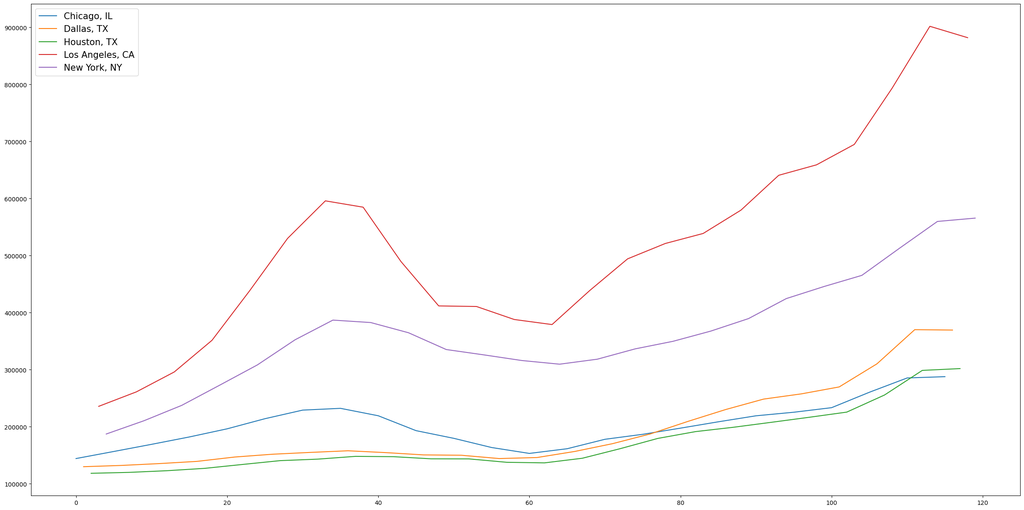

|  | Year | City | Average Price |
| --- | --- | --- | --- |
| 0 | 2000 | Chicago, IL | 144210.742048 |
| 1 | 2000 | Dallas, TX | 129926.866266 |
| 2 | 2000 | Houston, TX | 118371.138355 |
| 3 | 2000 | Los Angeles, CA | 235702.243852 |
| 4 | 2000 | New York, NY | 187211.522252 |
| ... | ... | ... | ... |
| 115 | 2023 | Chicago, IL | 287741.033592 |
| 116 | 2023 | Dallas, TX | 369431.030591 |
| 117 | 2023 | Houston, TX | 301907.494031 |
| 118 | 2023 | Los Angeles, CA | 881948.352043 |
| 119 | 2023 | New York, NY | 565669.086120 |

120 rows × 3 columns

```python
# Extract data of housing price average f| 5 highly populated cities in US
#pd.set_option('display.max_rows', 500)
prices = pd.read_csv('Metro_zhvi_uc_sfrcondo_tier_0.33_0.67_sm_sa_month.csv').head(6).tail(-1)
prices = pd.melt(prices, id_vars=['RegionName'], value_vars=prices.columns[5:])
prices['Date'] = pd.to_datetime(prices['variable'])
prices['Date'] = prices['Date'].astype('str')
prices = prices.drop('variable', axis=1).rename(columns={'value': 'Average Price'})
prices['Date'] = pd.DatetimeIndex(prices['Date'])
prices['Year'] = pd.DatetimeIndex(prices['Date']).year
prices.drop(columns='Date', axis=1)
display(prices)
prices = prices.groupby(['Year', 'RegionName']).aggregate(np.mean)
prices = prices.reset_index()
# Plot the avergae house price per month for each city
fig, ax = plt.subplots()
prices = prices.rename(columns={'RegionName': 'City'})
prices.groupby('City')['Average Price'].plot(x='Year', y='Average Price', figsize=(30, 15), ax=ax)
plt.legend(prop={'size': 15})
plt.rcParams.update({'font.size': 20})
plt.show()
prices
```

This is our code to gather data on the median house price for each of our 5 cities since 2000. All it is is a bunch of data tidying to organize our table into a readable format. We have also included a graph that shows how each city's median house price has changed based on the table.

```python
# This function drops rows that combine multiple cities (which makes no sense) after melting
def drop_invalid(df):
    cities = []
    for index, row in df.iterrows():
        if ('New York' in row['variable'] and row['City'] == 'New York, NY'):
            cities.append('New York, NY')
        elif ('Los Angeles' in row['variable'] and row['City'] == 'Los Angeles, CA'):
            cities.append('Los Angeles, CA')
        elif ('Chicago' in row['variable'] and row['City'] == 'Chicago, IL'):
            cities.append('Chicago, IL')
        elif ('Houston' in row['variable'] and row['City'] == 'Houston, TX'):
            cities.append('Houston, TX')
        elif ('Dallas' in row['variable'] and row['City'] == 'Dallas, TX'):
            cities.append('Dallas, TX')
        else:
            df = df.drop(index)

    df['City'] = cities
    return df.drop('variable',axis=1)


# Read the data
df = pd.read_csv('demographics.csv')
df['Year'] = pd.DatetimeIndex(df['date']).year
# Get recent data
df = df[(df['Year'] > 2011)]
df = df.drop('date', axis=1)

# DATA TIDYING. VERY MESSY, LOTS OF MELTING, BUT NECESSARY
df2 = df.head(10)
df = df.tail(-10)
df = df.groupby('Year').aggregate(np.mean)
df = df.fillna(df2.set_index('Year')).reset_index()

df = pd.melt(df, id_vars=['Year',
       'Los Angeles Count_Person_EducationalAttainmentBachelorsDegreeOrHigher',
       'Los Angeles Count_Person',
       'Chicago Count_Person_EducationalAttainmentBachelorsDegreeOrHigher',
       'Chicago Count_Person',
       'New York City Count_Person_EducationalAttainmentBachelorsDegreeOrHigher',
       'New York City Count_Person',
       'Dallas Count_Person_EducationalAttainmentBachelorsDegreeOrHigher',
       'Dallas Count_Person',
       'Houston Count_Person_EducationalAttainmentBachelorsDegreeOrHigher',
       'Houston Count_Person', 'Los Angeles UnemploymentRate_Person',
       'Chicago UnemploymentRate_Person',
       'New York City UnemploymentRate_Person',
       'Dallas UnemploymentRate_Person', 'Houston UnemploymentRate_Person',
       'Los Angeles Median_Income_Household',
       'Chicago Median_Income_Household',
       'New York City Median_Income_Household',
       'Dallas Median_Income_Household', 'Houston Median_Income_Household'], value_name='Population under poverty line',
             value_vars=['Los Angeles Count_Person_BelowPovertyLevelInThePast12Months', 'Chicago Count_Person_BelowPovertyLevelInThePast12Months',
             'New York City Count_Person_BelowPovertyLevelInThePast12Months',
            'Houston Count_Person_BelowPovertyLevelInThePast12Months',
            'Dallas Count_Person_BelowPovertyLevelInThePast12Months'])

cities = []
for index, row in df.iterrows():
    if ('New York City' in row['variable']):
        cities.append('New York, NY')
    elif ('Los Angeles' in row['variable']):
        cities.append('Los Angeles, CA')
    elif ('Chicago' in row['variable']):
        cities.append('Chicago, IL')
    elif ('Houston' in row['variable']):
        cities.append('Houston, TX')
    else:
        cities.append('Dallas, TX')

df['City'] = cities
df = df.drop('variable',axis=1)

df = pd.melt(df, id_vars=['Year', 'Population under poverty line', 'Los Angeles Count_Person', 'City',
                        'Chicago Count_Person',
                        'New York City Count_Person',
                        'Dallas Count_Person',
                        'Houston Count_Person', 'Los Angeles UnemploymentRate_Person',
                        'Chicago UnemploymentRate_Person',
                        'New York City UnemploymentRate_Person',
                        'Dallas UnemploymentRate_Person', 'Houston UnemploymentRate_Person',
                        'Los Angeles Median_Income_Household',
                        'Chicago Median_Income_Household',
                        'New York City Median_Income_Household',
                        'Dallas Median_Income_Household', 'Houston Median_Income_Household'], value_name='Population with Bachelors or Higher',
             value_vars=['Los Angeles Count_Person_EducationalAttainmentBachelorsDegreeOrHigher',
                        'Chicago Count_Person_EducationalAttainmentBachelorsDegreeOrHigher',
                        'New York City Count_Person_EducationalAttainmentBachelorsDegreeOrHigher',
                        'Dallas Count_Person_EducationalAttainmentBachelorsDegreeOrHigher',
                        'Houston Count_Person_EducationalAttainmentBachelorsDegreeOrHigher'])

df = drop_invalid(df)

df = pd.melt(df, id_vars=['Year', 'Population under poverty line', 'Population with Bachelors or Higher', 'City',
                            'Los Angeles UnemploymentRate_Person',
                            'Chicago UnemploymentRate_Person',
                            'New York City UnemploymentRate_Person',
                            'Dallas UnemploymentRate_Person', 'Houston UnemploymentRate_Person',
                            'Los Angeles Median_Income_Household',
                            'Chicago Median_Income_Household',
                            'New York City Median_Income_Household',
                            'Dallas Median_Income_Household', 'Houston Median_Income_Household'],
             value_name='Total Population', value_vars=['Los Angeles Count_Person',
                                                        'Chicago Count_Person',
                                                      'New York City Count_Person',
                                                        'Dallas Count_Person',
                                                        'Houston Count_Person'])
df = drop_invalid(df)
df = pd.melt(df, id_vars=['Year', 'Population under poverty line', 'Population with Bachelors or Higher', 'Total Population', 'City',
                        'Los Angeles Median_Income_Household',
                        'Chicago Median_Income_Household',
                        'New York City Median_Income_Household',
                        'Dallas Median_Income_Household', 'Houston Median_Income_Household'],
             value_name='Unemployment Rate', value_vars=['Los Angeles UnemploymentRate_Person',
                                                        'Chicago UnemploymentRate_Person',
                                                        'New York City UnemploymentRate_Person',
                                                        'Dallas UnemploymentRate_Person', 'Houston UnemploymentRate_Person'])
df = drop_invalid(df)
df = pd.melt(df, id_vars=['Year', 'City', 'Population under poverty line', 'Population with Bachelors or Higher', 'Total Population', 'Unemployment Rate'],
             value_name='Median Household Income', value_vars=['Los Angeles Median_Income_Household',
                                   'Chicago Median_Income_Household',
                                   'New York City Median_Income_Household',
                                   'Dallas Median_Income_Household', 'Houston Median_Income_Household'])
df = drop_invalid(df)

for index, row in df.iterrows():
    if (pd.isna(row['Population with Bachelors or Higher']) or pd.isna(row['Total Population']) or pd.isna(row['Unemployment Rate']) or pd.isna(row['Median Household Income'])):
        df = df.drop(index)
df = df.reset_index().drop('index', axis=1)
df['Percent of Population with Bachelors or Higher'] = 100 * df['Population with Bachelors or Higher'] / df['Total Population']
df['Percent of Population Under Poverty Line'] = 100 * df['Population under poverty line'] / df['Total Population']
df = df.drop('Population with Bachelors or Higher', axis=1).drop('Population under poverty line', axis=1)
df
```

|  | Year | City | Total Population | Unemployment Rate | Median Household Income | Percent of Population with Bachelors or Higher | Percent of Population Under Poverty Line |
| --- | --- | --- | --- | --- | --- | --- | --- |
| 0 | 2012 | Los Angeles, CA | 3847857.0 | 11.608333 | 49745.0 | 20.022236 | 20.554324 |
| 1 | 2013 | Los Angeles, CA | 3877721.0 | 10.325000 | 49497.0 | 20.266543 | 21.278761 |
| 2 | 2014 | Los Angeles, CA | 3904102.0 | 8.716667 | 49682.0 | 20.711677 | 21.789031 |
| 3 | 2015 | Los Angeles, CA | 3933644.0 | 7.075000 | 50205.0 | 21.255406 | 21.541909 |
| 4 | 2016 | Los Angeles, CA | 3957520.0 | 5.358333 | 51538.0 | 21.700282 | 20.945971 |
| 5 | 2017 | Los Angeles, CA | 3975067.0 | 4.841667 | 54501.0 | 22.310819 | 19.881929 |
| 6 | 2018 | Los Angeles, CA | 3981140.0 | 4.641667 | 58385.0 | 22.966286 | 18.620219 |
| 7 | 2019 | Los Angeles, CA | 3982885.0 | 4.483333 | 62142.0 | 23.662873 | 17.599077 |
| 8 | 2020 | Los Angeles, CA | 3889834.0 | 12.441667 | 65290.0 | 25.351827 | 16.935170 |
| 9 | 2012 | Chicago, IL | 2719039.0 | 10.033333 | 47408.0 | 22.021751 | 21.618189 |
| 10 | 2013 | Chicago, IL | 2725575.0 | 10.091667 | 47270.0 | 22.526219 | 22.064262 |
| 11 | 2014 | Chicago, IL | 2726800.0 | 7.908333 | 47831.0 | 23.130226 | 22.171336 |
| 12 | 2015 | Chicago, IL | 2724006.0 | 6.650000 | 48522.0 | 23.796093 | 21.836736 |
| 13 | 2016 | Chicago, IL | 2716297.0 | 6.525000 | 50434.0 | 24.653637 | 21.216053 |
| 14 | 2017 | Chicago, IL | 2710456.0 | 5.408333 | 52497.0 | 25.625983 | 20.307727 |
| 15 | 2018 | Chicago, IL | 2700968.0 | 4.391667 | 55198.0 | 26.513383 | 19.234771 |
| 16 | 2019 | Chicago, IL | 2691497.0 | 4.108333 | 58247.0 | 27.502910 | 18.139236 |
| 17 | 2020 | Chicago, IL | 2741730.0 | 11.500000 | 62097.0 | 28.214120 | 16.717656 |
| 18 | 2012 | New York, NY | 8346715.0 | 9.425000 | 51865.0 | 22.671207 | 19.209473 |
| 19 | 2013 | New York, NY | 8396207.0 | 8.800000 | 52259.0 | 23.169712 | 19.697668 |
| 20 | 2014 | New York, NY | 8433867.0 | 7.066667 | 52737.0 | 23.730455 | 20.114071 |
| 21 | 2015 | New York, NY | 8463157.0 | 5.575000 | 53373.0 | 24.437642 | 20.215530 |
| 22 | 2016 | New York, NY | 8468954.0 | 5.141667 | 55191.0 | 25.026999 | 19.952393 |
| 23 | 2017 | New York, NY | 8437695.0 | 4.508333 | 57782.0 | 25.976040 | 19.534814 |
| 24 | 2018 | New York, NY | 8396614.0 | 4.125000 | 60762.0 | 26.406418 | 18.706993 |
| 25 | 2019 | New York, NY | 8342925.0 | 3.941667 | 63998.0 | 27.104151 | 17.808910 |
| 26 | 2020 | New York, NY | 8772978.0 | 12.333333 | 67046.0 | 26.470042 | 16.222883 |
| 27 | 2012 | Dallas, TX | 1241950.0 | 7.000000 | 42436.0 | 17.789686 | 22.601151 |
| 28 | 2013 | Dallas, TX | 1258580.0 | 6.483333 | 42846.0 | 18.181045 | 22.777177 |
| 29 | 2014 | Dallas, TX | 1278737.0 | 5.333333 | 43359.0 | 18.373442 | 23.042502 |
| 30 | 2015 | Dallas, TX | 1300859.0 | 4.191667 | 43781.0 | 18.691034 | 22.934692 |
| 31 | 2016 | Dallas, TX | 1323587.0 | 4.008333 | 45215.0 | 19.185139 | 21.808842 |
| 32 | 2017 | Dallas, TX | 1342275.0 | 3.950000 | 47285.0 | 19.669740 | 20.912183 |
| 33 | 2018 | Dallas, TX | 1341692.0 | 3.825000 | 50100.0 | 20.523116 | 19.957039 |
| 34 | 2019 | Dallas, TX | 1343192.0 | 3.475000 | 52580.0 | 21.517549 | 18.560787 |
| 35 | 2020 | Dallas, TX | 1303234.0 | 8.025000 | 54747.0 | 23.346229 | 18.404983 |
| 36 | 2012 | Houston, TX | 2158700.0 | 6.383333 | 44648.0 | 17.802752 | 21.358132 |
| 37 | 2013 | Houston, TX | 2196367.0 | 5.908333 | 45010.0 | 18.120287 | 21.898481 |
| 38 | 2014 | Houston, TX | 2238653.0 | 4.875000 | 45728.0 | 18.474413 | 21.845056 |
| 39 | 2015 | Houston, TX | 2283616.0 | 4.333333 | 46187.0 | 18.918111 | 21.502871 |
| 40 | 2016 | Houston, TX | 2306360.0 | 5.050000 | 47010.0 | 19.455376 | 20.932422 |
| 41 | 2017 | Houston, TX | 2313079.0 | 4.941667 | 49399.0 | 20.124215 | 20.431295 |
| 42 | 2018 | Houston, TX | 2314478.0 | 4.333333 | 51140.0 | 20.689114 | 20.113347 |
| 43 | 2019 | Houston, TX | 2315720.0 | 3.783333 | 52338.0 | 21.347745 | 19.726694 |
| 44 | 2020 | Houston, TX | 2300027.0 | 8.983333 | 53600.0 | 22.639386 | 19.448728 |

We gathered this data off using a census tool that allows us to combine data into tables, which is how we got the csv. Although we initially had all the data in the table, it was unusable. In order to make it usable and readable, we had to melt it a good amount as you can see above. Although it was messy, we were able to tidy the data into one nice table that shows demographics data on the cities from 2012-2020.

```python
final_df = df.merge(prices, on=["City", "Year"])
final_df
display(prices)
display(df)
```

|  | Year | City | Average Price |
| --- | --- | --- | --- |
| 0 | 2000 | Chicago, IL | 144210.742048 |
| 1 | 2000 | Dallas, TX | 129926.866266 |
| 2 | 2000 | Houston, TX | 118371.138355 |
| 3 | 2000 | Los Angeles, CA | 235702.243852 |
| 4 | 2000 | New York, NY | 187211.522252 |
| ... | ... | ... | ... |
| 115 | 2023 | Chicago, IL | 287741.033592 |
| 116 | 2023 | Dallas, TX | 369431.030591 |
| 117 | 2023 | Houston, TX | 301907.494031 |
| 118 | 2023 | Los Angeles, CA | 881948.352043 |
| 119 | 2023 | New York, NY | 565669.086120 |

120 rows × 3 columns

|  | Year | City | Total Population | Unemployment Rate | Median Household Income | Percent of Population with Bachelors or Higher | Percent of Population Under Poverty Line |
| --- | --- | --- | --- | --- | --- | --- | --- |
| 0 | 2012 | Los Angeles, CA | 3847857.0 | 11.608333 | 49745.0 | 20.022236 | 20.554324 |
| 1 | 2013 | Los Angeles, CA | 3877721.0 | 10.325000 | 49497.0 | 20.266543 | 21.278761 |
| 2 | 2014 | Los Angeles, CA | 3904102.0 | 8.716667 | 49682.0 | 20.711677 | 21.789031 |
| 3 | 2015 | Los Angeles, CA | 3933644.0 | 7.075000 | 50205.0 | 21.255406 | 21.541909 |
| 4 | 2016 | Los Angeles, CA | 3957520.0 | 5.358333 | 51538.0 | 21.700282 | 20.945971 |
| 5 | 2017 | Los Angeles, CA | 3975067.0 | 4.841667 | 54501.0 | 22.310819 | 19.881929 |
| 6 | 2018 | Los Angeles, CA | 3981140.0 | 4.641667 | 58385.0 | 22.966286 | 18.620219 |
| 7 | 2019 | Los Angeles, CA | 3982885.0 | 4.483333 | 62142.0 | 23.662873 | 17.599077 |
| 8 | 2020 | Los Angeles, CA | 3889834.0 | 12.441667 | 65290.0 | 25.351827 | 16.935170 |
| 9 | 2012 | Chicago, IL | 2719039.0 | 10.033333 | 47408.0 | 22.021751 | 21.618189 |
| 10 | 2013 | Chicago, IL | 2725575.0 | 10.091667 | 47270.0 | 22.526219 | 22.064262 |
| 11 | 2014 | Chicago, IL | 2726800.0 | 7.908333 | 47831.0 | 23.130226 | 22.171336 |
| 12 | 2015 | Chicago, IL | 2724006.0 | 6.650000 | 48522.0 | 23.796093 | 21.836736 |
| 13 | 2016 | Chicago, IL | 2716297.0 | 6.525000 | 50434.0 | 24.653637 | 21.216053 |
| 14 | 2017 | Chicago, IL | 2710456.0 | 5.408333 | 52497.0 | 25.625983 | 20.307727 |
| 15 | 2018 | Chicago, IL | 2700968.0 | 4.391667 | 55198.0 | 26.513383 | 19.234771 |
| 16 | 2019 | Chicago, IL | 2691497.0 | 4.108333 | 58247.0 | 27.502910 | 18.139236 |
| 17 | 2020 | Chicago, IL | 2741730.0 | 11.500000 | 62097.0 | 28.214120 | 16.717656 |
| 18 | 2012 | New York, NY | 8346715.0 | 9.425000 | 51865.0 | 22.671207 | 19.209473 |
| 19 | 2013 | New York, NY | 8396207.0 | 8.800000 | 52259.0 | 23.169712 | 19.697668 |
| 20 | 2014 | New York, NY | 8433867.0 | 7.066667 | 52737.0 | 23.730455 | 20.114071 |
| 21 | 2015 | New York, NY | 8463157.0 | 5.575000 | 53373.0 | 24.437642 | 20.215530 |
| 22 | 2016 | New York, NY | 8468954.0 | 5.141667 | 55191.0 | 25.026999 | 19.952393 |
| 23 | 2017 | New York, NY | 8437695.0 | 4.508333 | 57782.0 | 25.976040 | 19.534814 |
| 24 | 2018 | New York, NY | 8396614.0 | 4.125000 | 60762.0 | 26.406418 | 18.706993 |
| 25 | 2019 | New York, NY | 8342925.0 | 3.941667 | 63998.0 | 27.104151 | 17.808910 |
| 26 | 2020 | New York, NY | 8772978.0 | 12.333333 | 67046.0 | 26.470042 | 16.222883 |
| 27 | 2012 | Dallas, TX | 1241950.0 | 7.000000 | 42436.0 | 17.789686 | 22.601151 |
| 28 | 2013 | Dallas, TX | 1258580.0 | 6.483333 | 42846.0 | 18.181045 | 22.777177 |
| 29 | 2014 | Dallas, TX | 1278737.0 | 5.333333 | 43359.0 | 18.373442 | 23.042502 |
| 30 | 2015 | Dallas, TX | 1300859.0 | 4.191667 | 43781.0 | 18.691034 | 22.934692 |
| 31 | 2016 | Dallas, TX | 1323587.0 | 4.008333 | 45215.0 | 19.185139 | 21.808842 |
| 32 | 2017 | Dallas, TX | 1342275.0 | 3.950000 | 47285.0 | 19.669740 | 20.912183 |
| 33 | 2018 | Dallas, TX | 1341692.0 | 3.825000 | 50100.0 | 20.523116 | 19.957039 |
| 34 | 2019 | Dallas, TX | 1343192.0 | 3.475000 | 52580.0 | 21.517549 | 18.560787 |
| 35 | 2020 | Dallas, TX | 1303234.0 | 8.025000 | 54747.0 | 23.346229 | 18.404983 |
| 36 | 2012 | Houston, TX | 2158700.0 | 6.383333 | 44648.0 | 17.802752 | 21.358132 |
| 37 | 2013 | Houston, TX | 2196367.0 | 5.908333 | 45010.0 | 18.120287 | 21.898481 |
| 38 | 2014 | Houston, TX | 2238653.0 | 4.875000 | 45728.0 | 18.474413 | 21.845056 |
| 39 | 2015 | Houston, TX | 2283616.0 | 4.333333 | 46187.0 | 18.918111 | 21.502871 |
| 40 | 2016 | Houston, TX | 2306360.0 | 5.050000 | 47010.0 | 19.455376 | 20.932422 |
| 41 | 2017 | Houston, TX | 2313079.0 | 4.941667 | 49399.0 | 20.124215 | 20.431295 |
| 42 | 2018 | Houston, TX | 2314478.0 | 4.333333 | 51140.0 | 20.689114 | 20.113347 |
| 43 | 2019 | Houston, TX | 2315720.0 | 3.783333 | 52338.0 | 21.347745 | 19.726694 |
| 44 | 2020 | Houston, TX | 2300027.0 | 8.983333 | 53600.0 | 22.639386 | 19.448728 |

Now, all we got to do is merge the two tables into one table with all our data for each year. This is what we will use for the future parts.

Part 3

After finishing the table, lets analyze some information in the table that might impact the price of the house in different cities. First, we want to do so visually by plotting out each factor.

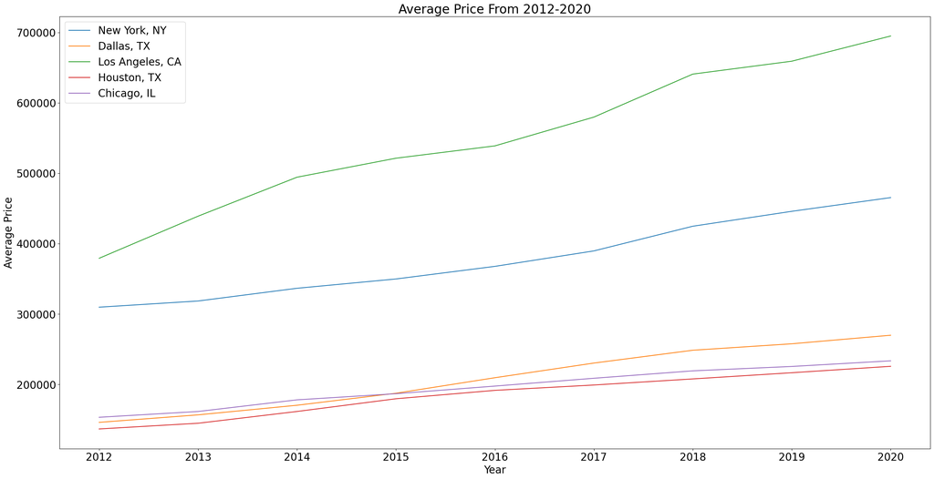

```python
# Draw a line plot of Average Price From 2012-2020
city_set = set(final_df['City'])

plt.figure(figsize=(30,15))
for city in city_set:
     selected_data = final_df.loc[final_df['City'] == city]
     plt.plot(selected_data['Year'], selected_data['Average Price'], label=city)

plt.title("Average Price From 2012-2020")
plt.xlabel("Year")
plt.ylabel("Average Price")
plt.legend()
plt.show()
```

This graph displays how the average house price for a given city changes between the years 2012 and 2020. We can see that housing prices steadily increase as the years go by.

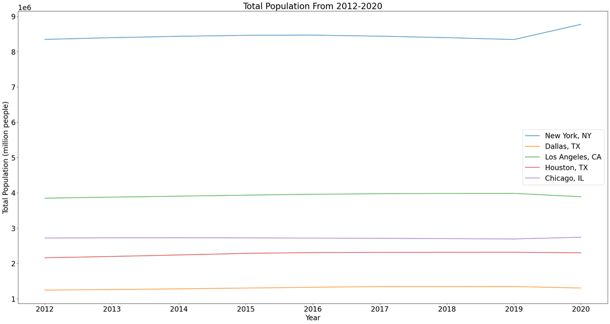

```python
# Draw a line plot of Total Population From 2012-2020
city_set = set(final_df['City'])

plt.figure(figsize=(30,15))
for city in city_set:
     selected_data = final_df.loc[final_df['City'] == city]
     plt.plot(selected_data['Year'], selected_data['Total Population'], label=city)

plt.title("Total Population From 2012-2020")
plt.xlabel("Year")
plt.ylabel("Total Population (million people)")
plt.legend()
plt.show()
```

This graph displays how the total population for a given city changes between the years 2012 and 2020. We can see there is not much change in population over the years

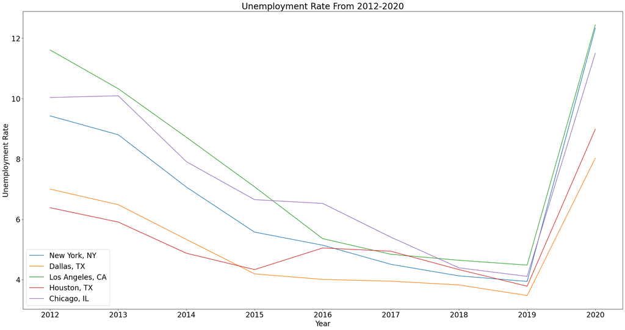

```python
# Draw a line plot of Unemployment Rate From 2012-2020
city_set = set(final_df['City'])

plt.figure(figsize=(30,15))
for city in city_set:
     selected_data = final_df.loc[final_df['City'] == city]
     plt.plot(selected_data['Year'], selected_data['Unemployment Rate'], label=city)

plt.title("Unemployment Rate From 2012-2020")
plt.xlabel("Year")
plt.ylabel("Unemployment Rate")
plt.legend()
plt.show()
```

This graph displays how the unemployment for a given city changes between the years 2012 and 2020. We can see this graph is pretty unpredictable. It has a lot of different peaks and valleys, but we can see that the rate of change does not differ much between the cities. This indicates that unemployment rate largely depends on the whole county's economic state. This is good because we are introducing a factor that does not differ much by city but rather is universal. A universal factor will allow the model to be more accurate universally and not just for certain cities.

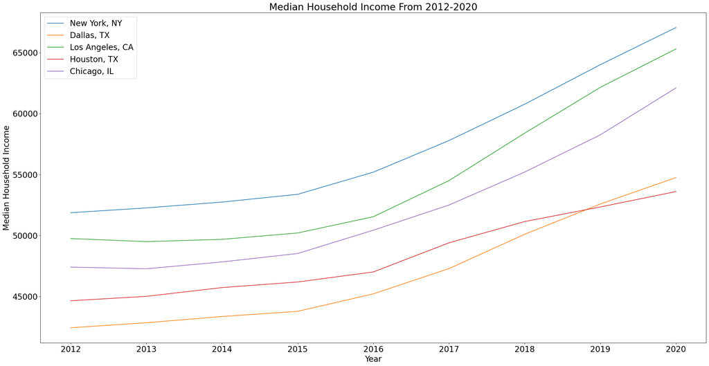

```python
# Draw a line plot of Median Household Income From 2012-2020
city_set = set(final_df['City'])

plt.figure(figsize=(30,15))
for city in city_set:
     selected_data = final_df.loc[final_df['City'] == city]
     plt.plot(selected_data['Year'], selected_data['Median Household Income'], label=city)

plt.title("Median Household Income From 2012-2020")
plt.xlabel("Year")
plt.ylabel("Median Household Income")
plt.legend()
plt.show()
```

This graph displays how the median household income for a given city changes between the years 2012 and 2020. We can see this increases relatively steadily for each city. It does not increase at the same rate as average housing price, which points to the why housing has become so unaffordable in recent years: because income has not kept up with increasing housing costs.

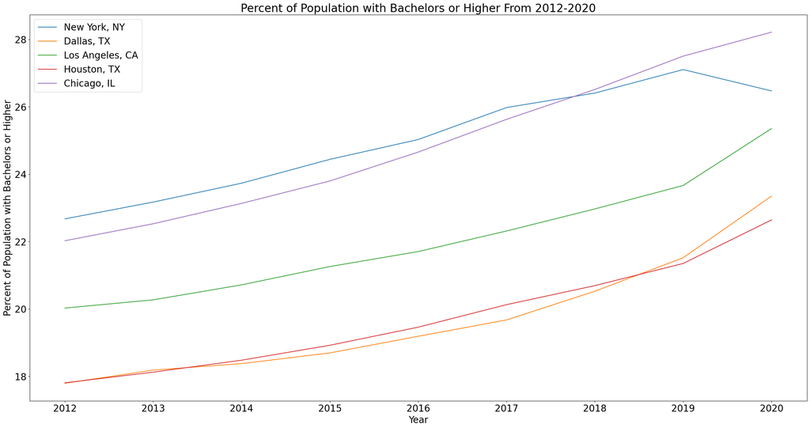

```python
# Draw a line plot of Percent of Population with Bachelors or Higher From 2012-2020
city_set = set(final_df['City'])

plt.figure(figsize=(30,15))
for city in city_set:
     selected_data = final_df.loc[final_df['City'] == city]
     plt.plot(selected_data['Year'], selected_data['Percent of Population with Bachelors or Higher'], label=city)

plt.title("Percent of Population with Bachelors or Higher From 2012-2020")
plt.xlabel("Year")
plt.ylabel("Percent of Population with Bachelors or Higher")
plt.legend()
plt.show()
```

This graph displays how the percent of population with a bachelor's degree for a given city changes between the years 2012 and 2020. This has increased steadily in the recent years. This can be attributed to the fact that college education is becoming more and more the standard to be successful and becoming more of the norm for people to pursue when graduating high school

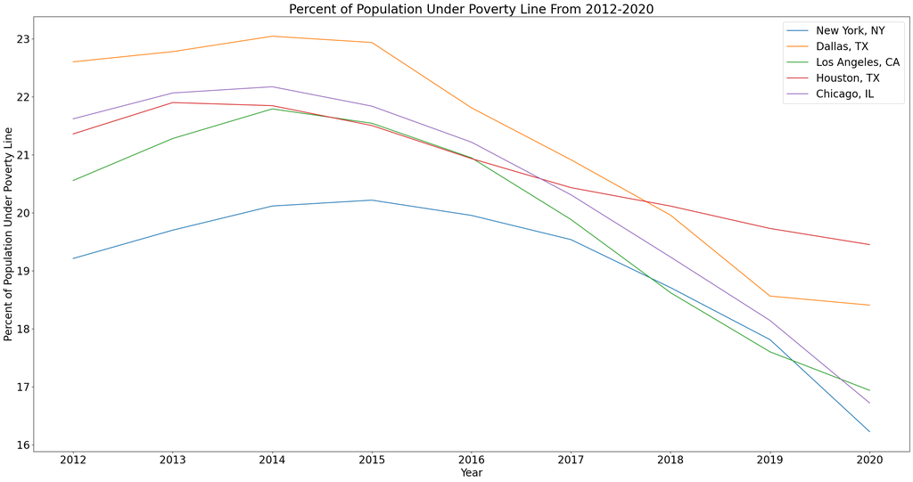

```python
# Draw a line plot of Percent of Population Under Poverty Line From 2012-2020
city_set = set(final_df['City'])

plt.figure(figsize=(30,15))
for city in city_set:
     selected_data = final_df.loc[final_df['City'] == city]
     plt.plot(selected_data['Year'], selected_data['Percent of Population Under Poverty Line'], label=city)

plt.title("Percent of Population Under Poverty Line From 2012-2020")
plt.xlabel("Year")
plt.ylabel("Percent of Population Under Poverty Line")
plt.legend()
plt.show()
```

Since the average house price has a trend that is increasing constantly, we want to find out that what might be the reasons leads to the increaing price. So we are going to draw a correlation matrix to find out the relationships between those factors and average house price.

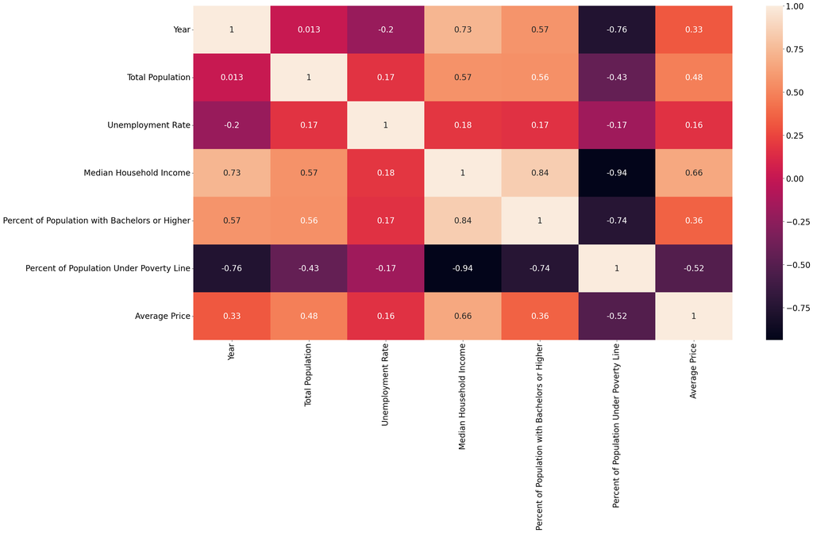

```python
plt.figure(figsize=(30,15))
correlation_matrix = final_df.corr()
sns.heatmap(correlation_matrix, annot=True)
plt.show()
```

Part 4

We are going to build an initial regression model to predict the house price between different cities.

```python
final_df = final_df.rename(columns={
   'Total Population': 'total_population',
   'Unemployment Rate': 'unemployment_rate',
    'Median Household Income': 'median_household_income',
    'Percent of Population with Bachelors or Higher': 'percent_bachelors_or_higher',
    'Percent of Population Under Poverty Line': 'percent_under_poverty_line',
    'Average Price': 'average_price',
})
```

```python
# Label encoding for the categorical variable 'City'
le = LabelEncoder()
final_df['City'] = le.fit_transform(final_df['City'])

# Defining predictors and target variable
X_initial = final_df[['City', 'total_population', 'median_household_income', 'percent_bachelors_or_higher',
        'unemployment_rate', 'percent_under_poverty_line', 'Year']]
y = final_df['average_price']

# Splitting the data into train and test sets
X_train, X_test, y_train, y_test = train_test_split(X_initial, y, test_size=0.2, random_state=42)

# Defining the model
initial_model = RandomForestRegressor(n_estimators=100, random_state=42)

# Fitting the model
initial_model.fit(X_train, y_train)

# Predicting the test set results
y_pred = initial_model.predict(X_test)

# Evaluating the model
mse = mean_squared_error(y_test, y_pred)
print("MSE: ", mse)
print("RMSE: ", mse**(0.5))
```

```
MSE:  2202284562.198089
RMSE:  46928.50479397451
```

The Mean Squared Error (MSE) and Root Mean Squared Error (RMSE) are both measures of model accuracy, with lower values indicating better performance.

```python
average_predicted_price = np.mean(y_pred)
print("The average predicted house price is: ", average_predicted_price)
```

```
The average predicted house price is:  342289.78632498893
```

We got our model, to verify its validity, we are going to do some predictions for the house price in the New York City.

```python
# Assuming you have a new data point for the new city
new_city_data = {'City': [4], 'total_population': [8433867], 'median_household_income': [63998],
                 'percent_bachelors_or_higher': [0.27351827], 'unemployment_rate': [0.441667],
                 'percent_under_poverty_line': [0.17116053], 'Year': [2023]}

new_df = pd.DataFrame(new_city_data)

# Convert all 'City' values in the original dataframe to strings and perform label encoding
final_df['City'] = final_df['City'].astype(str)
le = LabelEncoder()
final_df['City'] = le.fit_transform(final_df['City'])

# Separate predictors and target variable for the original data and train the model
X_initial = final_df[['City', 'total_population', 'median_household_income', 'percent_bachelors_or_higher',
        'unemployment_rate', 'percent_under_poverty_line', 'Year']]
y = final_df['average_price']

# Fit the model
initial_model.fit(X_initial, y)

# Convert 'City' in new data to string, encode it and make a prediction
new_df['City'] = new_df['City'].astype(str)
new_city_encoded = le.transform(new_df['City'])
new_df['City'] = new_city_encoded

# Now you can predict the house price for the new city
new_city_prediction = initial_model.predict(new_df)

# Print out the prediction
print("Predicted average house price for the new city: ", new_city_prediction[0])
```

```
Predicted average house price for the new city:  473217.23922716186
```

Let's try some tactics that might be able to improve the accruary of the prediction model. First try Feature Engineering strategy.

```python
final_df['income_per_population'] = final_df['median_household_income'] / final_df['total_population']
final_df['population_bachelors_interaction'] = final_df['total_population'] * final_df['percent_bachelors_or_higher']
final_df['population_squared'] = final_df['total_population'] ** 2
```

```python
# Don't forget to add the new feature to the new city data as well
new_df['income_per_population'] = new_df['median_household_income'] / new_df['total_population']
new_df['population_bachelors_interaction'] = new_df['total_population'] * new_df['percent_bachelors_or_higher']
new_df['population_squared'] = new_df['total_population'] ** 2

# Redefine feature set to include the new feature
X_new = final_df[['City', 'total_population', 'median_household_income',
              'percent_bachelors_or_higher', 'unemployment_rate', 'percent_under_poverty_line',
              'Year', 'income_per_population', 'population_bachelors_interaction', 'population_squared']]

# Splitting the data into train and test sets
X_train, X_test, y_train, y_test = train_test_split(X_new, y, test_size=0.2, random_state=42)

# Defining the model
new_model = RandomForestRegressor(n_estimators=100, random_state=42)

# Fitting the model
new_model.fit(X_train, y_train)

# Predicting the test set results
y_pred = new_model.predict(X_test)


# Now you can predict the house price for the new city using the updated model
new_city_prediction = new_model.predict(new_df)

# Print out the prediction
print("Predicted average house price for the new city: ", new_city_prediction[0])
```

```
Predicted average house price for the new city:  409011.44185124204
```

We want to know which model is better suits for our circumstance, so we are going to compare their Cross-validation (This helps to evaluate the model's performance more robustly).

```python
# Perform cross-validation
scores = cross_val_score(initial_model, X_initial, y, cv=5, scoring='neg_mean_squared_error')

# Print out the mean of the cross-validation scores
print("Cross-validated MSE: ", -scores.mean())

# Perform cross-validation
scores = cross_val_score(new_model, X_new, y, cv=5, scoring='neg_mean_squared_error')

# Print out the mean of the cross-validation scores
print("Cross-validated MSE: ", -scores.mean())
```

```
Cross-validated MSE:  36214328159.20153
Cross-validated MSE:  39831493902.30622
```

After comparing the Cross-validated MSE, we want to choose the one that has a smaller number (it has a smaller error, meaning its predictions are, on average, closer to the actual values.), so we are actully going to use the model before reenforcement, which is the initial_model

Part 5

Now, We are going to apply our best model to some data from a few other cities and see what we get. Lets start off by gathering the average house price per year for 3 cities each year.

```python
prices2 = pd.read_csv('Metro_zhvi_uc_sfrcondo_tier_0.33_0.67_sm_sa_month.csv')
prices2 = prices2[(prices2['RegionName'] == 'Baltimore, MD') | (prices2['RegionName'] == 'Phoenix, AZ') | (prices2['RegionName'] == 'Philadelphia, PA')]
prices2 = pd.melt(prices2, id_vars=['RegionName'], value_vars=prices2.columns[5:])
prices2['Date'] = pd.to_datetime(prices2['variable'])
prices2['Date'] = prices2['Date'].astype('str')
prices2 = prices2.drop('variable', axis=1).rename(columns={'value': 'Average Price'})
prices2['Date'] = pd.DatetimeIndex(prices2['Date'])
prices2['Year'] = pd.DatetimeIndex(prices2['Date']).year
prices2.drop(columns='Date', axis=1)
prices2 = prices2.groupby(['Year', 'RegionName']).aggregate(np.mean)
prices2 = prices2.reset_index()
prices2 = prices2.rename(columns={'RegionName': 'City'})
display(prices2)
```

|  | Year | City | Average Price |
| --- | --- | --- | --- |
| 0 | 2000 | Baltimore, MD | 134258.774548 |
| 1 | 2000 | Philadelphia, PA | 115665.156339 |
| 2 | 2000 | Phoenix, AZ | 144632.665203 |
| 3 | 2001 | Baltimore, MD | 141078.072327 |
| 4 | 2001 | Philadelphia, PA | 122779.261379 |
| ... | ... | ... | ... |
| 67 | 2022 | Philadelphia, PA | 317249.357627 |
| 68 | 2022 | Phoenix, AZ | 452392.557295 |
| 69 | 2023 | Baltimore, MD | 351797.456311 |
| 70 | 2023 | Philadelphia, PA | 325776.476348 |
| 71 | 2023 | Phoenix, AZ | 436748.768114 |

72 rows × 3 columns

Now, let's gather some demographics data on these cities that we will input into the model. This is done the exact same way as in Part 1.

```python
def drop_invalid(df):
    cities = []
    for index, row in df.iterrows():
        if ('Philadelphia' in row['variable'] and row['City'] == 'Philadelphia, PA'):
            cities.append('Philadelphia, PA')
        elif ('Phoenix' in row['variable'] and row['City'] == 'Phoenix, AZ'):
            cities.append('Phoenix, AZ')
        elif ('Baltimore' in row['variable'] and row['City'] == 'Baltimore, MD'):
            cities.append('Baltimore, MD')
        else:
            df = df.drop(index)

    df['City'] = cities
    return df.drop('variable',axis=1)
# Read the data
demographics2 = pd.read_csv('demographics2.csv')
demographics2['Year'] = pd.DatetimeIndex(demographics2['date']).year
# Get recent data
demographics2 = demographics2[(demographics2['Year'] > 2011)]
demographics2 = demographics2.drop('date', axis=1)

# DATA TIDYING. VERY MESSY, LOTS OF MELTING, BUT NECESSARY
demographics22 = demographics2.head(10)
demographics2 = demographics2.tail(-10)
demographics2 = demographics2.groupby('Year').aggregate(np.mean)
demographics2 = demographics2.fillna(demographics22.set_index('Year')).reset_index()
demographics2 = demographics2[(demographics2['Year'] < 2021)]

demographics2 = pd.melt(demographics2, id_vars=['Year',
       'Phoenix Count_Person_EducationalAttainmentBachelorsDegreeOrHigher',
       'Phoenix Count_Person',
       'Baltimore Count_Person_EducationalAttainmentBachelorsDegreeOrHigher',
       'Baltimore Count_Person',
       'Philadelphia Count_Person_EducationalAttainmentBachelorsDegreeOrHigher',
       'Philadelphia Count_Person',
       'Baltimore UnemploymentRate_Person',
       'Philadelphia UnemploymentRate_Person',
       'Phoenix UnemploymentRate_Person',
       'Phoenix Median_Income_Household',
       'Baltimore Median_Income_Household',
       'Philadelphia Median_Income_Household'], value_name='Population under poverty line',
             value_vars=['Phoenix Count_Person_BelowPovertyLevelInThePast12Months', 'Baltimore Count_Person_BelowPovertyLevelInThePast12Months',
             'Philadelphia Count_Person_BelowPovertyLevelInThePast12Months',])
cities = []
for index, row in demographics2.iterrows():
    if ('Philadelphia' in row['variable']):
        cities.append('Philadelphia, PA')
    elif ('Phoenix' in row['variable']):
        cities.append('Phoenix, AZ')
    else:
        cities.append('Baltimore, MD')

demographics2['City'] = cities
demographics2 = demographics2.drop('variable',axis=1)

demographics2 = pd.melt(demographics2, id_vars=['Year', 'Population under poverty line', 'Phoenix Count_Person', 'City',
                        'Baltimore Count_Person',
                        'Philadelphia Count_Person', 'Phoenix UnemploymentRate_Person',
                        'Baltimore UnemploymentRate_Person',
                        'Philadelphia UnemploymentRate_Person',
                        'Phoenix Median_Income_Household',
                        'Baltimore Median_Income_Household',
                        'Philadelphia Median_Income_Household'], value_name='Population with Bachelors or Higher',
             value_vars=['Phoenix Count_Person_EducationalAttainmentBachelorsDegreeOrHigher',
                        'Baltimore Count_Person_EducationalAttainmentBachelorsDegreeOrHigher',
                        'Philadelphia Count_Person_EducationalAttainmentBachelorsDegreeOrHigher'])
demographics2 = drop_invalid(demographics2)
demographics2 = pd.melt(demographics2, id_vars=['Year', 'Population under poverty line', 'Population with Bachelors or Higher', 'City',
                            'Phoenix UnemploymentRate_Person',
                            'Baltimore UnemploymentRate_Person',
                            'Philadelphia UnemploymentRate_Person',
                            'Phoenix Median_Income_Household',
                            'Baltimore Median_Income_Household',
                            'Philadelphia Median_Income_Household'],
             value_name='Total Population', value_vars=['Phoenix Count_Person',
                                                        'Baltimore Count_Person',
                                                      'Philadelphia Count_Person'])
demographics2 = drop_invalid(demographics2)

demographics2 = pd.melt(demographics2, id_vars=['Year', 'Population under poverty line', 'Population with Bachelors or Higher', 'Total Population', 'City',
                        'Phoenix Median_Income_Household',
                        'Baltimore Median_Income_Household',
                        'Philadelphia Median_Income_Household'],
             value_name='Unemployment Rate', value_vars=['Phoenix UnemploymentRate_Person',
                                                        'Baltimore UnemploymentRate_Person',
                                                        'Philadelphia UnemploymentRate_Person'])
demographics2 = drop_invalid(demographics2)
demographics2 = pd.melt(demographics2, id_vars=['Year', 'City', 'Population under poverty line', 'Population with Bachelors or Higher', 'Total Population', 'Unemployment Rate'],
             value_name='Median Household Income', value_vars=['Phoenix Median_Income_Household',
                                   'Baltimore Median_Income_Household',
                                   'Philadelphia Median_Income_Household'])
demographics2 = drop_invalid(demographics2)

for index, row in demographics2.iterrows():
    if (pd.isna(row['Population with Bachelors or Higher']) or pd.isna(row['Total Population']) or pd.isna(row['Unemployment Rate']) or pd.isna(row['Median Household Income'])):
        demographics2 = demographics2.drop(index)
demographics2 = demographics2.reset_index().drop('index', axis=1)
demographics2['Percent of Population with Bachelors or Higher'] = 100 * demographics2['Population with Bachelors or Higher'] / demographics2['Total Population']
demographics2['Percent of Population Under Poverty Line'] = 100 * demographics2['Population under poverty line'] / demographics2['Total Population']
demographics2 = demographics2.drop('Population with Bachelors or Higher', axis=1).drop('Population under poverty line', axis=1)
demographics2
```

|  | Year | City | Total Population | Unemployment Rate | Median Household Income | Percent of Population with Bachelors or Higher | Percent of Population Under Poverty Line |
| --- | --- | --- | --- | --- | --- | --- | --- |
| 0 | 2012 | Phoenix, AZ | 1499250.0 | 7.800000 | 47866.0 | 15.515691 | 20.981491 |
| 1 | 2013 | Phoenix, AZ | 1526505.0 | 6.950000 | 47139.0 | 15.746624 | 21.715422 |
| 2 | 2014 | Phoenix, AZ | 1555485.0 | 6.091667 | 46881.0 | 15.827989 | 21.953346 |
| 3 | 2015 | Phoenix, AZ | 1583760.0 | 5.366667 | 47326.0 | 16.034626 | 21.864803 |
| 4 | 2016 | Phoenix, AZ | 1612303.0 | 4.816667 | 49328.0 | 16.619705 | 21.296183 |
| 5 | 2017 | Phoenix, AZ | 1633704.0 | 4.400000 | 52080.0 | 16.914508 | 19.915358 |
| 6 | 2018 | Phoenix, AZ | 1655082.0 | 4.250000 | 54765.0 | 17.430013 | 18.658955 |
| 7 | 2019 | Phoenix, AZ | 1682933.0 | 4.241667 | 57459.0 | 17.817049 | 17.233841 |
| 8 | 2020 | Phoenix, AZ | 1611345.0 | 7.933333 | 60914.0 | 19.536040 | 16.429629 |
| 9 | 2012 | Baltimore, MD | 623035.0 | 10.025000 | 40803.0 | 17.147191 | 22.457005 |
| 10 | 2013 | Baltimore, MD | 622591.0 | 9.591667 | 41385.0 | 17.802377 | 22.833931 |
| 11 | 2014 | Baltimore, MD | 623833.0 | 8.433333 | 41819.0 | 18.501907 | 23.219195 |
| 12 | 2015 | Baltimore, MD | 622831.0 | 7.400000 | 42241.0 | 19.357097 | 22.743569 |
| 13 | 2016 | Baltimore, MD | 616542.0 | 6.375000 | 44262.0 | 20.342977 | 22.377064 |
| 14 | 2017 | Baltimore, MD | 610853.0 | 5.925000 | 46641.0 | 21.177435 | 21.902651 |
| 15 | 2018 | Baltimore, MD | 603241.0 | 5.533333 | 48840.0 | 21.983751 | 21.356141 |
| 16 | 2019 | Baltimore, MD | 594601.0 | 4.875000 | 50379.0 | 22.735919 | 20.927647 |
| 17 | 2020 | Baltimore, MD | 583132.0 | 8.541667 | 52164.0 | 23.753627 | 19.936824 |
| 18 | 2012 | Philadelphia, PA | 1552087.0 | 10.650000 | 37016.0 | 14.676948 | 25.084419 |
| 19 | 2013 | Philadelphia, PA | 1558713.0 | 9.975000 | 37192.0 | 15.260282 | 25.392038 |
| 20 | 2014 | Philadelphia, PA | 1565949.0 | 8.225000 | 37460.0 | 15.806773 | 25.621460 |
| 21 | 2015 | Philadelphia, PA | 1571679.0 | 7.233333 | 38253.0 | 16.557261 | 25.409260 |
| 22 | 2016 | Philadelphia, PA | 1576604.0 | 6.700000 | 39770.0 | 17.302125 | 24.886148 |
| 23 | 2017 | Philadelphia, PA | 1581699.0 | 6.358333 | 40649.0 | 18.008230 | 24.905118 |
| 24 | 2018 | Philadelphia, PA | 1586422.0 | 5.708333 | 43744.0 | 19.161106 | 24.008303 |
| 25 | 2019 | Philadelphia, PA | 1584439.0 | 5.516667 | 45927.0 | 20.113807 | 23.587339 |
| 26 | 2020 | Philadelphia, PA | 1601005.0 | 12.241667 | 49127.0 | 21.113613 | 22.163079 |

Now, we merge the prices and demographics just like Part 1 to get a readable table.

```python
test_data = demographics2.merge(prices2, on=["City", "Year"])
test_data
```

|  | Year | City | Total Population | Unemployment Rate | Median Household Income | Percent of Population with Bachelors or Higher | Percent of Population Under Poverty Line | Average Price |
| --- | --- | --- | --- | --- | --- | --- | --- | --- |
| 0 | 2012 | Phoenix, AZ | 1499250.0 | 7.800000 | 47866.0 | 15.515691 | 20.981491 | 146678.055531 |
| 1 | 2013 | Phoenix, AZ | 1526505.0 | 6.950000 | 47139.0 | 15.746624 | 21.715422 | 180794.912973 |
| 2 | 2014 | Phoenix, AZ | 1555485.0 | 6.091667 | 46881.0 | 15.827989 | 21.953346 | 202000.225804 |
| 3 | 2015 | Phoenix, AZ | 1583760.0 | 5.366667 | 47326.0 | 16.034626 | 21.864803 | 213519.301029 |
| 4 | 2016 | Phoenix, AZ | 1612303.0 | 4.816667 | 49328.0 | 16.619705 | 21.296183 | 233501.198216 |
| 5 | 2017 | Phoenix, AZ | 1633704.0 | 4.400000 | 52080.0 | 16.914508 | 19.915358 | 249124.710918 |
| 6 | 2018 | Phoenix, AZ | 1655082.0 | 4.250000 | 54765.0 | 17.430013 | 18.658955 | 269144.439339 |
| 7 | 2019 | Phoenix, AZ | 1682933.0 | 4.241667 | 57459.0 | 17.817049 | 17.233841 | 286940.268566 |
| 8 | 2020 | Phoenix, AZ | 1611345.0 | 7.933333 | 60914.0 | 19.536040 | 16.429629 | 315845.040647 |
| 9 | 2012 | Baltimore, MD | 623035.0 | 10.025000 | 40803.0 | 17.147191 | 22.457005 | 219752.415971 |
| 10 | 2013 | Baltimore, MD | 622591.0 | 9.591667 | 41385.0 | 17.802377 | 22.833931 | 230503.466488 |
| 11 | 2014 | Baltimore, MD | 623833.0 | 8.433333 | 41819.0 | 18.501907 | 23.219195 | 241472.805762 |
| 12 | 2015 | Baltimore, MD | 622831.0 | 7.400000 | 42241.0 | 19.357097 | 22.743569 | 246076.231589 |
| 13 | 2016 | Baltimore, MD | 616542.0 | 6.375000 | 44262.0 | 20.342977 | 22.377064 | 252477.335733 |
| 14 | 2017 | Baltimore, MD | 610853.0 | 5.925000 | 46641.0 | 21.177435 | 21.902651 | 260708.681395 |
| 15 | 2018 | Baltimore, MD | 603241.0 | 5.533333 | 48840.0 | 21.983751 | 21.356141 | 269762.115147 |
| 16 | 2019 | Baltimore, MD | 594601.0 | 4.875000 | 50379.0 | 22.735919 | 20.927647 | 278051.196590 |
| 17 | 2020 | Baltimore, MD | 583132.0 | 8.541667 | 52164.0 | 23.753627 | 19.936824 | 290078.690229 |
| 18 | 2012 | Philadelphia, PA | 1552087.0 | 10.650000 | 37016.0 | 14.676948 | 25.084419 | 184512.001133 |
| 19 | 2013 | Philadelphia, PA | 1558713.0 | 9.975000 | 37192.0 | 15.260282 | 25.392038 | 187201.871382 |
| 20 | 2014 | Philadelphia, PA | 1565949.0 | 8.225000 | 37460.0 | 15.806773 | 25.621460 | 193206.079752 |
| 21 | 2015 | Philadelphia, PA | 1571679.0 | 7.233333 | 38253.0 | 16.557261 | 25.409260 | 198753.854191 |
| 22 | 2016 | Philadelphia, PA | 1576604.0 | 6.700000 | 39770.0 | 17.302125 | 24.886148 | 207101.490894 |
| 23 | 2017 | Philadelphia, PA | 1581699.0 | 6.358333 | 40649.0 | 18.008230 | 24.905118 | 216775.353288 |
| 24 | 2018 | Philadelphia, PA | 1586422.0 | 5.708333 | 43744.0 | 19.161106 | 24.008303 | 227112.353798 |
| 25 | 2019 | Philadelphia, PA | 1584439.0 | 5.516667 | 45927.0 | 20.113807 | 23.587339 | 236749.818841 |
| 26 | 2020 | Philadelphia, PA | 1601005.0 | 12.241667 | 49127.0 | 21.113613 | 22.163079 | 252995.115179 |

Below, we fit the model to our 3 cities and compare the predicted median house price to the actual median house price for each year and city. We do this by calculating the error between the 2 values.

```python
test_data['City'] = le.fit_transform(test_data['City'])
test_data = test_data.rename(columns={
   'Total Population': 'total_population',
   'Unemployment Rate': 'unemployment_rate',
    'Median Household Income': 'median_household_income',
    'Percent of Population with Bachelors or Higher': 'percent_bachelors_or_higher',
    'Percent of Population Under Poverty Line': 'percent_under_poverty_line',
    'Average Price': 'average_price',
})
# Now you can predict the house price for the new cities
test_data_prediction = initial_model.predict(test_data[['City', 'total_population', 'median_household_income', 'percent_bachelors_or_higher',
        'unemployment_rate', 'percent_under_poverty_line', 'Year']])

# Add prediction and error to datafrane
test_data['Predicted Prices'] = test_data_prediction
test_data['Error'] = abs(100 * (test_data['average_price'] - test_data['Predicted Prices']) / test_data['average_price'])
```

To better visualize the accuracy, I plotted the percent error for each city and year that the model predicted below.

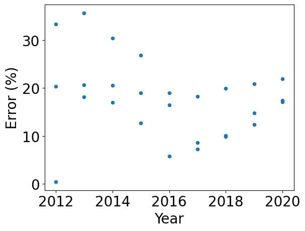

```python
test_data.plot.scatter(x='Year', y='Error');
plt.ylabel('Error (%)');
```

Here, we can see the model was anywhere between 1% and 35% off from the actual value with a mean of around 15%. This indicates that the model is inaccurate, but it does get the prediction in the ballpark of what the actual value is.

Part 6

Let's analyze our model. We tested our model on 3 other cities. The model was, in my opionion, surprisingly accurate. It was only around, on average, 15% off when trying to predict the average housing price in a given city for a given year. That is pretty good. To put it in perspective, If the average housing price in a city for a given year was 200,000 dollars,the model is likely to predict on average that the avergae housing price for that city in that year is 170,000 dolars. While this is not exactly right, it does give a ballpark estimate that isn't too far off from the actual value. So, what does this mean?

For one, we can say that there is a somewhat strong correlation between the given demographics and the average housing price for a city. The way these demographics data change does play some role in how housing prices change for a city. Although we can conclude this, we also have to analyze the flip side. The model is off a lot of time. This means that there are other factors besides the demographics data we already factored in that play a role in constituting how housing prices change. We completely expected this. These mysterious factors can be climate of the city, economic state of the city/country like the stock market, how fast houses are being built, etc. We now know for sure that there are a broad range of factors that must be considered when trying to predict housing prices.

Would you use this model to try and predict housing prices in the future? For me, I likely wouldn't put that must trust in it, but there are other uses for it. Let me propose this question: how will we know how much these demographics play a role in housing prices for a year? Well, we can use the error of this model. If the error is low, then for the given year and city, the average housing price is likely heavily influenced by thee factors. If the error is high, then other factors not considered in this model probably play a bigger role. There are many used of this model beyond its prediction capabilities. It gives us a sense of what's really important to the housing market.